# Sampling bias in radiocarbon dating project: broad approach 2 using the AustArch database

### Frequency distributions of sites with dates within time bins

Calculate the frequency distribution for each data set:

```r
taphCorrect = FALSE    ## whether to taphonomically correct the open sites - not currently as haven't specified whether sites are open
correctForSite = TRUE  ## per bin: number of sites with at least one date in them, or number of dates within the bin total
binSize = 100          ## the size of the bins to use (years) - use a bin size that actually fits the timeRange specified

# Get median bin age for x axis (same for all)
median.bin.age   <- seq(timeRange[2] + binSize/2, timeRange[1] - binSize/2, by = binSize)

# Baseline data
fd.baseline.site <- generate_frequency_dist(data = baseline.data,
                                            calibrated_data = cal.baseline.data,
                                            timeRange = timeRange,
                                            taphCorrect = taphCorrect,
                                            correctForSite = correctForSite,
                                            binSize = binSize)

# Baseline + singleton
fd.baseline.plus.s.site  <- generate_frequency_dist(data = baseline.plus.s,
                                                    calibrated_data = cal.baseline.plus.s,
                                                    timeRange = timeRange,
                                                    taphCorrect = taphCorrect,
                                                    correctForSite = correctForSite,
                                                    binSize = binSize)
# Baseline + bracketed
fd.baseline.plus.b.site   <- generate_frequency_dist(data = baseline.plus.b,
                                                     calibrated_data = cal.baseline.plus.b,
                                                     timeRange = timeRange,
                                                     taphCorrect = taphCorrect,
                                                     correctForSite = correctForSite,
                                                     binSize = binSize)

# Baseline + singleton + bracketed
fd.baseline.plus.s.d.site  <- generate_frequency_dist(data = baseline.plus.s.b,
                                                      calibrated_data = cal.baseline.plus.s.b,
                                                      timeRange = timeRange,
                                                      taphCorrect = taphCorrect,
                                                      correctForSite = correctForSite,
                                                      binSize = binSize)
```

Plot the resulting frequency distributions:  
* dashed black line is the frequency distribution for the baseline data set  
* solid teal line is the frequency distribution for the baseline + singleton data * solid orange line is the frequency distribution for the baseline + bracketed data * sp;od blue line is the frequency distribution for the baseline + singleton + bracketed data

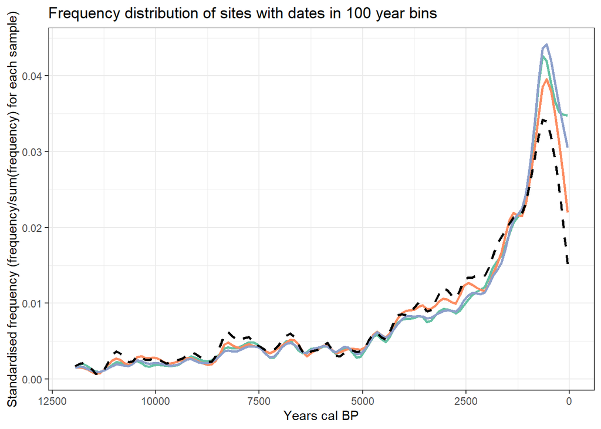